# Protocol variables

Compounds included in document:

```
## [1] "MEPA_total" "ETPA_total" "BPA_total"  "OXBE_total" "TRCS_total"
```

# 1 Intro

In this document we analyse the link between the following protocol variables: **batch**, **defreeze time**, and **transport time** (with a special focus on batch) and the urinary levels of phenols with less than 30% samples < LOQ.

This analysis is limited to **pregnancy data**.

The life cycle of a urine sample in sepages is:

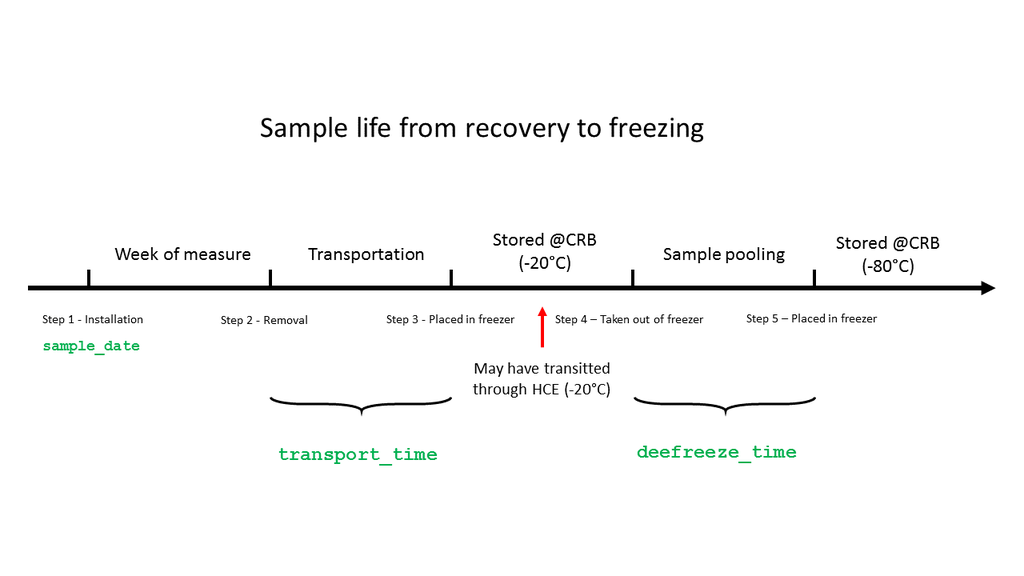

Sample process in sepages

# 2 Batch

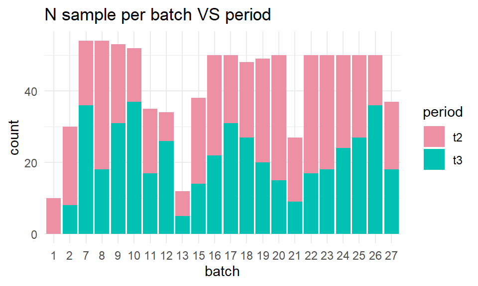

As we have previously seen there is a link between season on many compound levels it is interesting to note season variability between batches:

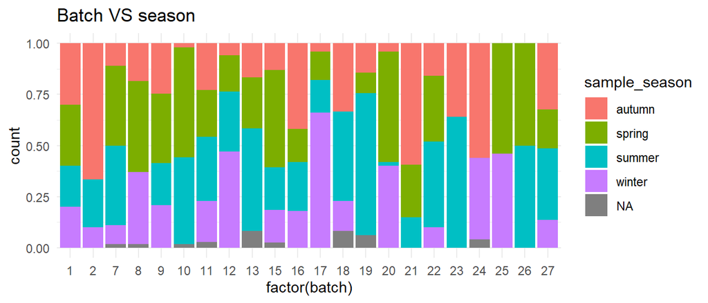

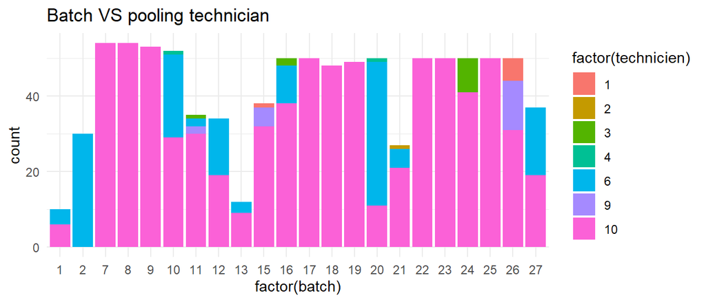

- Batch 17 used as reference because high N, high proportion of “winter” the reference category of the season variable and both present for both phthalates and phenols (code generalisability)